# Data Science Term Project: Prudential Risk Analysis

Laszlo Sallo

February, 2016

## Introduction

The subject of this Term Project is a risk analysis provided task by Prudential Life Insurance through a Kaggle Competition. The full description of the challenge: https://www.kaggle.com/c/prudential-life-insurance-assessment.

More about Kaggle: https://www.kaggle.com/about

The goal is well summarized as *“developing a predictive model that accurately classifies risk using a more automated approach, you can greatly impact public perception of the industry.”*

## The data

By the nature of the Kaggle competitions, I got no full description of the features in the train set. This makes the feature engineering harder or less effective, because I cannot really use much domain knowledge to create strong predictors.

Description of the columns in the trains set:

- **Id** - A unique identifier associated with an application.
- **Product_Info_1-7** - A set of normalized variables relating to the product applied for
- **Ins_Age** - Normalized age of applicant
- **Ht** - Normalized height of applicant
- **Wt** - Normalized weight of applicant
- **BMI** - Normalized BMI of applicant
- **Employment_Info_1-6** - A set of normalized variables relating to the employment history of the applicant
- **InsuredInfo_1-6** - A set of normalized variables providing information about the applicant
- **Insurance_History_1-9** - A set of normalized variables relating to the insurance history of the applicant
- **Family_Hist_1-5** - A set of normalized variables relating to the family history of the applicant
- **Medical_History_1-41** - A set of normalized variables relating to the medical history of the applicant
- **Medical_Keyword_1-48** - A set of dummy variables relating to the presence of/absence of a medical keyword being associated with the application
- **Response** - This is the target variable, an ordinal variable relating to the final decision associated with an application

## Types of data

Categorical (nominal):

- Product_Info_1-3, 5-7
- Employment_Info_2, 3, 5
- InsuredInfo_1-7
- Insurance_History_1-4, 7-9
- Family_Hist_1
- Medical_History_2-9, 11-14, 16-23, 25-41

Continuous:

- Product_Info_4
- Ins_Age
- Ht
- Wt
- BMI
- Employment_Info_1, 4, 6
- Insurance_History_5
- Family_Hist_2-5;

Discrete:

- Medical_History_1
- Medical_History_10, 15, 24, 32

Dummy:

- Medical_Keyword_1-48

## Evaluation of the model

The models are scored based on the quadratic weighted kappa, which measures the agreement between two ratings. This metric typically varies from 0 (random agreement) to 1 (complete agreement). In the event that there is less agreement between the raters than expected by chance, this metric may go below 0. The response variable has 8 possible ratings. Each application is characterized by a tuple, which corresponds to its scores by Rater A (actual risk) and Rater B (predicted risk).

## Exploratory Analysis

Some mandatory steps, before we start the real job:

```r
#loading libraries
library(h2o)
library(readr)
library(dplyr)
library(ggplot2)
library(h2oEnsemble)
library(knitr)
library(pander)

#in case h2oEnsemble needs to be installed
#library(devtools)
#install.packages("https://h2o-release.s3.amazonaws.com/h2o-ensemble/R/h2oEnsemble_0.1.5.tar.gz", repos = NULL)


#set seed for reproducible research
set.seed(1976)
```

Kaggle provided two csv files:

- train data which ultimately will be split in train/validation and test data. This test data is not to be mistaken with the next set. Kaggle limits the number of daily tests to 5, so if I want to make tests more often I need my own test set
- test data which is actually the submission data I will use to send and test my results to Kaggle (this test is actually 30% of the total test data, on the end of the competition Kaggle will apply my results to a larger model to test overfitting)

```r
#load data
trainlocal <- read_csv("data/prudential_train.csv")
testlocal  <- read_csv("data/prudential_test.csv")
appendixtrainlocal <- trainlocal
```

```r
dim(trainlocal)
```

```
## [1] 59381   128
```

```r
dim(testlocal)
```

```
## [1] 19765   127
```

```r
str(trainlocal,list.len=ncol(trainlocal))
```

```
## Classes 'tbl_df', 'tbl' and 'data.frame':    59381 obs. of  128 variables:
##  $ Id                 : int  2 5 6 7 8 10 11 14 15 16 ...
##  $ Product_Info_1     : int  1 1 1 1 1 1 1 1 1 1 ...
##  $ Product_Info_2     : chr  "D3" "A1" "E1" "D4" ...
##  $ Product_Info_3     : int  10 26 26 10 26 26 10 26 26 21 ...
##  $ Product_Info_4     : num  0.0769 0.0769 0.0769 0.4872 0.2308 ...
##  $ Product_Info_5     : int  2 2 2 2 2 3 2 2 2 2 ...
##  $ Product_Info_6     : int  1 3 3 3 3 1 3 3 3 3 ...
##  $ Product_Info_7     : int  1 1 1 1 1 1 1 1 1 1 ...
##  $ Ins_Age            : num  0.6418 0.0597 0.0299 0.1642 0.4179 ...
##  $ Ht                 : num  0.582 0.6 0.745 0.673 0.655 ...
##  $ Wt                 : num  0.149 0.132 0.289 0.205 0.234 ...
##  $ BMI                : num  0.323 0.272 0.429 0.352 0.424 ...
##  $ Employment_Info_1  : num  0.028 0 0.03 0.042 0.027 0.325 0.11 0.12 0.165 0.025 ...
##  $ Employment_Info_2  : int  12 1 9 9 9 15 1 12 9 1 ...
```

[output cut: 114 more lines]

A more comprehensive statistics is presented in the Appendix.

The backbone of my toolset for this task was R (Ver. 3.2.3) and H2O server (Build 3.6.0.8). For exploring the data I could use both of these tools, but I used mostly the H2O dashboard, because with 100+ features I found more comfortable to quickly access any time any statistics.

Further, I am going to present some of my findings, more precisely the ones which are the base of my later feature engineering:

### Target: Response

8 levels of rates, rate 3,4 is a bit underrepresented comparing the rest. I cannot do much about it.

```r
summary(trainlocal$Response)
```

```
##    Min. 1st Qu.  Median    Mean 3rd Qu.    Max.
##   1.000   4.000   6.000   5.637   8.000   8.000
```

```r
trainlocal %>% group_by(Response) %>% summarize(n = n()) %>% mutate(pc = n/sum(n)*100)
```

```
## Source: local data frame [8 x 3]
##
##   Response     n        pc
##      (int) (int)     (dbl)
## 1        1  6207 10.452838
## 2        2  6552 11.033832
## 3        3  1013  1.705933
## 4        4  1428  2.404810
## 5        5  5432  9.147707
## 6        6 11233 18.916825
## 7        7  8027 13.517792
## 8        8 19489 32.820262
```

### Predictor: Medical_History_15

A lots of missing values, strong presence on both ends. Create a binary feature, by converting missing values to 0 and cutting the dataset in 2.

```r
summary(trainlocal$Medical_History_15)
```

```
##    Min. 1st Qu.  Median    Mean 3rd Qu.    Max.    NA's
##     0.0    17.0   117.0   123.8   240.0   240.0   44596
```

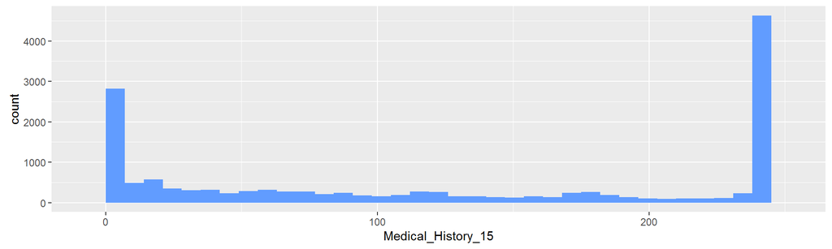

```r
ggplot(trainlocal) + geom_histogram(aes(x = Medical_History_15),na.rm = TRUE,binwidth = 7,fill="#619cff")
```

### Predictor: Medical_History_24

Similar to the previous is this one, a lot of missing data, but the splitting won’t work because not much on the right end (however I tried)

```r
summary(trainlocal$Medical_History_24)
```

```
##    Min. 1st Qu.  Median    Mean 3rd Qu.    Max.    NA's
##    0.00    1.00    8.00   50.64   64.00  240.00   55580
```

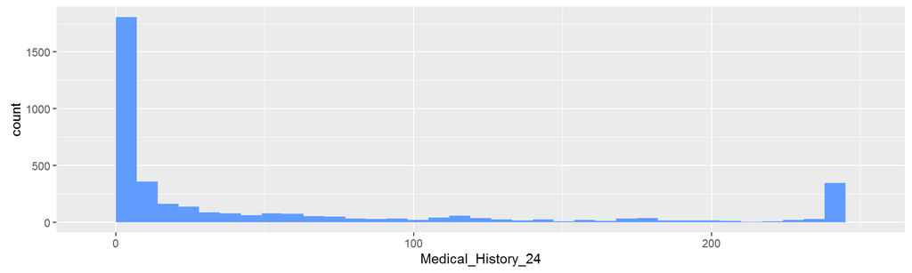

```r
ggplot(trainlocal) + geom_histogram(aes(x = Medical_History_24),na.rm = TRUE,binwidth = 7,fill="#619cff")
```

### Predictor: Product_Info_2

Character codes, code to numbers, alternatively create feature out of the first and second character

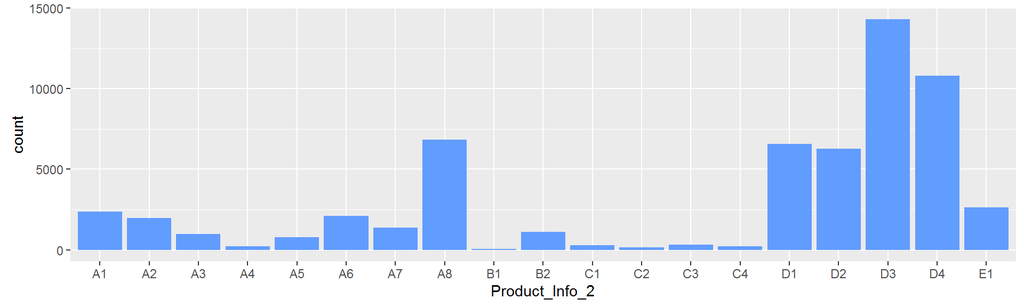

```r
ggplot(trainlocal) + geom_bar(aes(x = Product_Info_2),na.rm = TRUE,fill="#619cff" )
```

### Predictor: Product_Info_4

```r
summary(trainlocal$Product_Info_4)
```

```
##    Min. 1st Qu.  Median    Mean 3rd Qu.    Max.
## 0.00000 0.07692 0.23080 0.32900 0.48720 1.00000
```

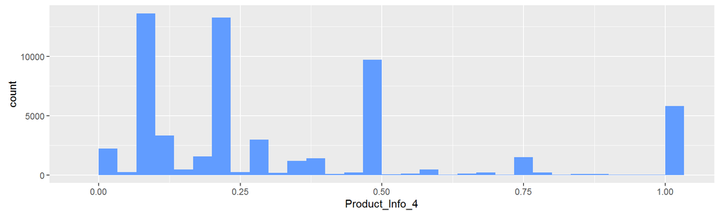

```r
ggplot(trainlocal) + geom_histogram(aes(x = Product_Info_4),bins  = 30,fill="#619cff")
```

### Predictor: BMI

BMI means different for different age groups, so a new feature with the interaction of BMI with Age makes sense.

```r
summary(trainlocal$BMI)
```

```
##    Min. 1st Qu.  Median    Mean 3rd Qu.    Max.
##  0.0000  0.3855  0.4513  0.4695  0.5329  1.0000
```

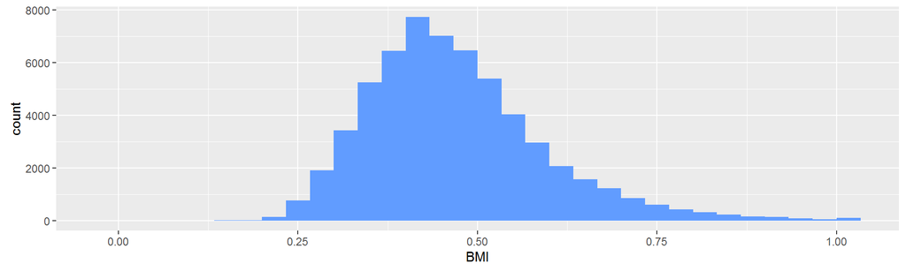

```r
ggplot(trainlocal) + geom_histogram(aes(x = BMI),bins  = 30,fill="#619cff")
```

### Predictor: Ins_Age

```r
summary(trainlocal$Ins_Age)
```

```
##    Min. 1st Qu.  Median    Mean 3rd Qu.    Max.
##  0.0000  0.2388  0.4030  0.4056  0.5672  1.0000
```

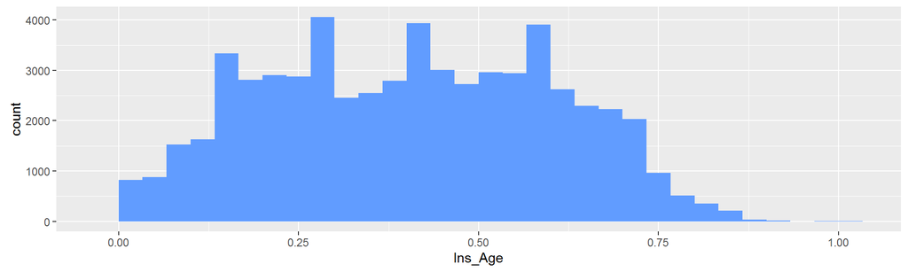

```r
ggplot(trainlocal) + geom_histogram(aes(x = Ins_Age),bins  = 30,fill="#619cff")
```

### Predictor: Family_Hist_2

A lots of missing data in both, nice distribution on the rest, product of these 2 feature can result in a strong one?

```r
summary(trainlocal$Family_Hist_2)
```

```
##    Min. 1st Qu.  Median    Mean 3rd Qu.    Max.    NA's
##   0.000   0.362   0.464   0.475   0.580   1.000   28656
```

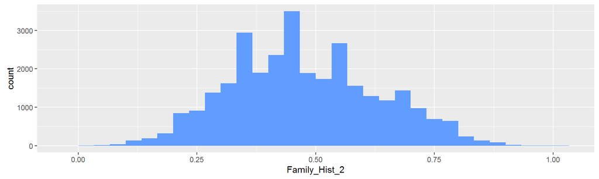

```r
ggplot(trainlocal) + geom_histogram(aes(x = Family_Hist_2),na.rm = TRUE,bins = 30,fill="#619cff")
```

###Predictor: Family_Hist_4

```r
summary(trainlocal$Family_Hist_4)
```

```
##    Min. 1st Qu.  Median    Mean 3rd Qu.    Max.    NA's
##   0.000   0.324   0.422   0.445   0.563   0.944   19184
```

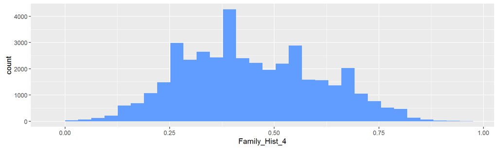

```r
ggplot(trainlocal) + geom_histogram(aes(x = Family_Hist_4),na.rm = TRUE,bins  = 30,fill="#619cff")
```

## Feature Engineering

New feature: Medical_History_15 NA to 0, cut at 5.

```r
trainlocal$custom1 <- as.numeric(trainlocal$Medical_History_15 < 5.0)
trainlocal$custom1[is.na(trainlocal$custom1)] <- 0.0
testlocal$custom1 <- as.numeric(testlocal$Medical_History_15 < 5.0)
testlocal$custom1[is.na(testlocal$custom1)] <- 0.0
```

New feature: Product_Info_4 cut at 0.075.

```r
trainlocal$custom2 <- as.numeric(trainlocal$Product_Info_4 < 0.075)
testlocal$custom2 <- as.numeric(testlocal$Product_Info_4 < 0.075)
```

New feature: Product_Info_4 binary value == 1 and the rest.

```r
trainlocal$custom3 <- as.numeric(trainlocal$Product_Info_4 == 1)
testlocal$custom3 <- as.numeric(testlocal$Product_Info_4 == 1)
```

New feature: BMI * Age.

```r
trainlocal$custom6 <- trainlocal$BMI * trainlocal$Ins_Age
testlocal$custom6 <- testlocal$BMI * testlocal$Ins_Age
```

New feature: Family_Hist_4 * Family_Hist_2.

```r
trainlocal$custom10 <- trainlocal$Family_Hist_4 * trainlocal$Family_Hist_2
testlocal$custom10 <- testlocal$Family_Hist_4 * testlocal$Family_Hist_2
```

New features: create new features based on the characters of Product_Info_2 (which was initially a 2 character string).

```r
trainlocal$Product_Info_2_char <- as.factor(substr(trainlocal$Product_Info_2, 1,1))
trainlocal$Product_Info_2_num <- as.factor(substr(trainlocal$Product_Info_2, 2,2))
testlocal$Product_Info_2_char <- as.factor(substr(testlocal$Product_Info_2, 1,1))
testlocal$Product_Info_2_num <- as.factor(substr(testlocal$Product_Info_2, 2,2))
```

New feature: Character to Factor(Product_Info_2)

```r
feature.names <- colnames(trainlocal)

for (f in feature.names) {
  if (class(trainlocal[[f]])=="character") {
    levels <- unique(c(trainlocal[[f]], testlocal[[f]]))
    trainlocal[[f]] <- as.integer(factor(trainlocal[[f]], levels=levels))
    testlocal[[f]]  <- as.integer(factor(testlocal[[f]],  levels=levels))
  }
}
```

New feature: Count where where the a Medical_Keyword is present, I hope that this is an indicator to the general general health of the applicant.

```r
trainlocal <- trainlocal %>% mutate(mkcount = rowSums(.[grep("Medical_Keyword_1$", colnames(trainlocal)):grep("Medical_Keyword_48$", colnames(trainlocal))]))
testlocal <- testlocal %>% mutate(mkcount = rowSums(.[grep("Medical_Keyword_1$", colnames(testlocal)):grep("Medical_Keyword_48$", colnames(testlocal))]))
```

```r
#prmitive way to place response on the end
response <- trainlocal$Response
trainlocal$Response <- NULL
trainlocal$Response <- response
```

## Modeling

I met various challenges in the modeling phase. First, as stated in the introduction we have no classes but rates, which means a higher rate includes the lower rate. Altogether, this is a regression problem rather than a classification. As consequence the models will generate decimal numbers approximately between 0 and 8. The challenge here is to find the a way how to cut (or round) these numbers to obtain the final integer rating.

This leads us to the second challenge: the final evaluation of the model is the QuadraticWeightedKappa indicator, so in order to evaluate the model we first need a cut and then to calculate the indicator. This operation is not supported by the machine learning algorithms so I had to select another metrics for validation.

I have tried several option how to deal with this problem, on the end these were the steps which gave me the best result.

- build a model with validation or cross-validation using mse (mean squared error)
- choose the model with the lowest MSE
- use the optim command, which is an mathematical optimization algorithm, on the train set to find the cut which result the lowest ScoreQuadraticWeightedKappa
- predict the test result and cut with the values obtained the previous step

```r
#check error for a given cut
SQWKfun = function(x = seq(1.5, 7.5, by = 1), preds,trues) {
  cuts = c(min(preds), x[1], x[2], x[3], x[4], x[5], x[6], x[7], max(preds))
  preds = as.numeric(Hmisc::cut2(preds, cuts))
  err = Metrics::ScoreQuadraticWeightedKappa(preds, trues, 1, 8)
  return(-err)
}


#evaluate model and calculate optimal cutting
eval = function(model,train,trainf,mytest,mytestf) {

  response <- predict(model, train)
  result <- as.data.frame(response$pred)[,1]
  optCuts <- optim(seq(1.5, 7.5, by = 1), SQWKfun, preds = result, trues = trainf$Response)
  cat("cuts ", optCuts$par,"\n\n")
  pred = predict(model, mytest)
  result <- as.numeric(Hmisc::cut2(as.data.frame(pred$pred)[,1], c(-Inf, optCuts$par, Inf)))
  print(table(result))
  err = Metrics::ScoreQuadraticWeightedKappa(result, mytestf$Response, 1, 8)
  cat("quadratic weighted kappa ", err)
  return(err)
}
```

### H2o server and data upload

My machine learning engine was mainly a remote h2o server. I played around with a 3 node cluster, but it turned out that as long as the data sets fits in the memory it is better to do on one node, because the transaction overhead between the nodes is higher than gain of having more CPU cores. The server i used was pretty powerful anyway, 32 CPU cores and 256G RAM is more than an average home use. To speed up my analysis is used multiple variations of the codes against multiple single nodes.

```r
h2o.init(ip="xxx2.dev.xxxx.io", port=54321, max_mem_size = "64g", nthreads = -1,startH2O = FALSE)
```

```
## Successfully connected to http://xxx2.dev.xxxx.io:54321/
##
## R is connected to the H2O cluster:
##     H2O cluster uptime:         6 days 12 hours
##     H2O cluster version:        3.6.0.8
##     H2O cluster name:           lsallo
##     H2O cluster total nodes:    1
##     H2O cluster total memory:   26.60 GB
##     H2O cluster total cores:    32
##     H2O cluster allowed cores:  32
##     H2O cluster healthy:        TRUE
```

```
## IP Address: xxx2.dev.xxxx.io
## Port      : 54321
## Session ID: _sid_a4379d61ad2a4a1ea619fd134b0e4912
## Key Count : 0
```

```r
#h2o.init(max_mem_size = "4g", nthreads = -1)

#define set sizes
validrows <- 5000
testrows <- 5000
N <- nrow(trainlocal)
```

Split the train data in:

- train set: `4.9381\times 10^{4}`
- validation set: `5000`
- test set: `5000`

```r
#split data
idx_train <- sample(1:N,N- (validrows+testrows))
idx_valid <- sample(base::setdiff(1:N, idx_train), validrows)
idx_test <- base::setdiff(base::setdiff(1:N, idx_train),idx_valid)

trainf <- trainlocal[idx_train,]
validf <- trainlocal[idx_valid,]
mytestf <- trainlocal[idx_test,]
```

Upload to h2o the resulted sets + the submition tests set.

```r
#upload to h2o
train <- as.h2o(trainf)
test <- as.h2o(testlocal)
mytest <- as.h2o(mytestf)
valid <- as.h2o(validf)
```

Convert factors to numbers (for some reason this gave me better results)

```r
#factor to number
train$Product_Info_2_char <- as.numeric(train$Product_Info_2_char)
test$Product_Info_2_char <- as.numeric(test$Product_Info_2_char)
mytest$Product_Info_2_char <- as.numeric(mytest$Product_Info_2_char)
valid$Product_Info_2_char <- as.numeric(valid$Product_Info_2_char)

train$Product_Info_2_num <- as.numeric(train$Product_Info_2_num)
test$Product_Info_2_num <- as.numeric(test$Product_Info_2_num)
mytest$Product_Info_2_num <- as.numeric(mytest$Product_Info_2_num)
valid$Product_Info_2_num <- as.numeric(valid$Product_Info_2_num)
```

```r
#define vars
independentVariables = names(train)[3:ncol(train)-1]
dependentVariable = names(train)[ncol(train)]
```

### Random Forest

Being the simplest model, with few tuning parameters, first I tried the Random Forest.

```r
#random forest
system.time({
modelRF <- h2o.randomForest(x = independentVariables, y = dependentVariable,
                          seed = 1976,training_frame = train, validation_frame=valid,
                          mtries = -1, ntrees =500, max_depth = 20, nbins = 200)
})
```

```r
#MSE
mseRF <- h2o.mse(modelRF,train=TRUE,valid=TRUE)
print(mseRF)
```

```
##    train    valid
## 3.466036 3.432132
```

```r
errRF <- eval(modelRF,train,trainf,mytest,mytestf)
```

```
## cuts  2.781709 3.613986 4.332713 4.775877 5.385934 6.031175 6.806409
##
## result
##    1    2    3    4    5    6    7    8
##  260  372  374  362  503  765  828 1536
## quadratic weighted kappa  0.6361118
```

### GBM

My second model GBM which was meant to beat RF. Later I tuned this model with grid search, what I present here is already the tuned model.

```r
#gbm
system.time({
modelGBM <- h2o.gbm(x=independentVariables, y=dependentVariable, seed = 1976,training_frame = train, validation_frame=valid,
                 learn_rate=0.035, max_depth=11, nbins=20, ntrees =500, sample_rate=0.6,min_rows=10,stopping_rounds = 3)
})
```

```r
#MSE
mseGBM <- h2o.mse(modelGBM,train=TRUE,valid=TRUE)
print(mseGBM)
```

```
##    train    valid
## 1.930308 3.288681
```

```r
errGBM <- eval(modelGBM,train,trainf,mytest,mytestf)
```

```
## cuts  2.837413 3.627501 4.115772 4.69571 5.388089 6.107148 6.888857
##
## result
##    1    2    3    4    5    6    7    8
##  349  371  228  366  586  745  860 1495
## quadratic weighted kappa  0.6535638
```

### GBM Grid

I run several grid searches, first I started with large intervals and bigger gaps and I iteratively converged to the ideal settings.

```r
#grid search
system.time({
modelGrid <- h2o.grid("gbm", x = independentVariables, y = dependentVariable,
                  training_frame = train, validation_frame = valid,
                  hyper_params = list(ntrees = 300,
                                      max_depth = c(8),
                                      learn_rate = c(0.03, 0.035),
                                      nbins = c(20),
                                      min_rows = c(3,10),
                                      sample_rate=c(0.6,1),
                                      seed=1976),
                  stopping_rounds = 3, stopping_tolerance = 1e-3)

})
```

```r
gridResult <- do.call(rbind, lapply(modelGrid@model_ids, function(m_id) {
  mm <- h2o.getModel(m_id)
  hyper_params <- mm@allparameters
  data.frame(mse = h2o.mse(mm, valid=TRUE),
             max_depth = hyper_params$max_depth,
             learn_rate = hyper_params$learn_rate,
             nbins = hyper_params$nbins,
             min_rows = hyper_params$min_rows,
             sample_rate = hyper_params$sample_rate

  )
})) %>% arrange(desc(mse))

gridResult
```

```
##        mse max_depth learn_rate nbins min_rows sample_rate
## 1 3.316919         8      0.030    20       10         1.0
## 2 3.311250         8      0.035    20        3         1.0
## 3 3.309627         8      0.035    20       10         1.0
## 4 3.306737         8      0.030    20        3         1.0
## 5 3.302765         8      0.035    20        3         0.6
## 6 3.300433         8      0.035    20       10         0.6
## 7 3.298077         8      0.030    20        3         0.6
## 8 3.287388         8      0.030    20       10         0.6
```

### GBM with cross validation

The advantage of cross validation is that we don’t need validation data, so I can train my model on a larger dataset and still I can avoid over fitting. Using larger data, the expectation is to have a better model.

```r
idx_train <- sample(1:N,N-5000)
idx_test <- base::setdiff(1:N, idx_train)
idx_valid <- 0


trainf <- trainlocal[idx_train,]
validf <- trainlocal[idx_valid,]
mytestf <- trainlocal[idx_test,]


train <- as.h2o(trainlocal)
mytest <- as.h2o(mytestf)

#factor to number
train$Product_Info_2_char <- as.numeric(train$Product_Info_2_char)
mytest$Product_Info_2_char <- as.numeric(mytest$Product_Info_2_char)

train$Product_Info_2_num <- as.numeric(train$Product_Info_2_num)
mytest$Product_Info_2_num <- as.numeric(mytest$Product_Info_2_num)
```

```r
modelGBMCV <- h2o.gbm(x=independentVariables, y=dependentVariable, seed = 1976,training_frame = train,
                  learn_rate=0.035, max_depth=11, nbins=20, ntrees =500, sample_rate=0.6,min_rows=10,nfolds = 5,stopping_rounds = 3)
```

```r
#MSE
mseGBMCV <- h2o.mse(modelGBMCV,train=TRUE,xval = TRUE)
print(mseGBMCV)
```

```
##    train     xval
## 2.257038 3.350073
```

```r
errGBMCV <- eval(modelGBMCV,train,trainlocal,mytest,mytestf)
```

```
## cuts  2.923627 3.542906 4.281954 4.73115 5.406896 6.121768 6.773326
##
## result
##    1    2    3    4    5    6    7    8
##  483  240  350  280  572  721  750 1604
## quadratic weighted kappa  0.7983274
```

### Performance of various models

As expected in the GMBCV obtained the highest QuadraticWeightedKappa Score, even though the train MSE was a bit higher than for GBM. (Worth to study: is it generally the cross fold MSE higher than the dedicated MSE ? ) The random forest was not really able to obtain a low MSE, so the QuadraticWeightedKappa Score was accordingly lower than the rest.

```
##   x msevalid msetrain       swq labels
## 1 1 3.432132 3.466036 0.6361118     RF
## 2 2 3.288681 1.930308 0.6535638    GBM
## 3 3 3.350073 2.257038 0.7983274  GBMCV
```

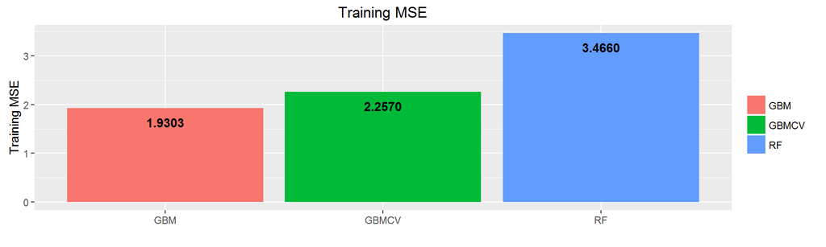

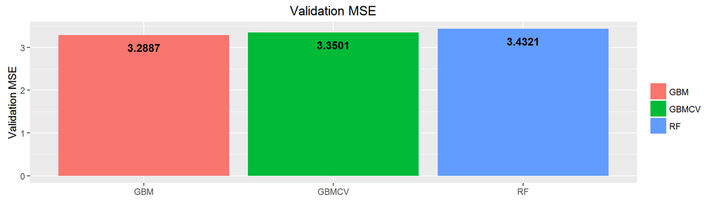

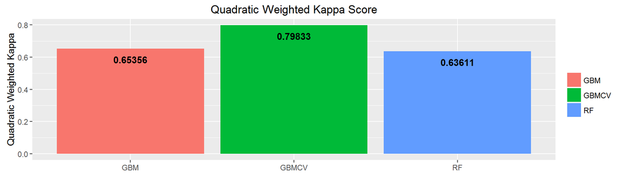

### Ensembles

My final model was an ensemble of models, of 3 types: Random Forest, GBM and Deep Learning. The get the right parameters for the first and the second I used grid search, similar to the previous one. For deep learning I had no time to play around, because the competition was about to close, so I used the recommended settings from the h2o ensemble tutorial.

For the so called metalearner, I first used “SL.glm” from the SuperLearner packages, but it turned out that the h2o deep learning outperforms it. (this was not the case few month back)

To build my final ensemble took around 6 hours, so I did not had too much window to play around with the setup. Even so, this was the best performing model I made in this study. (The code below uses smaller trees to able the create this report in fashionable time)

First I had to define the model wrappers. In my initial code, this was wrapper generation was dynamic (See appendix), but for some reason I was not able to make it work with Rmarkdown, so on the end I copied in the Rmarkdown, the output of the dynamic functions.

```r
h2o.rf.11 <- function(..., ntrees =250, nbins = 20,seed = 1,sample_rate = 0.1)
  h2o.randomForest.wrapper(..., ntrees = ntrees, nbins = nbins,sample_rate = sample_rate, seed = seed)
h2o.rf.12 <- function(..., ntrees =250, nbins = 20,seed = 1,sample_rate = 0.632)
  h2o.randomForest.wrapper(..., ntrees = ntrees, nbins = nbins,sample_rate = sample_rate, seed = seed)
h2o.rf.13 <- function(..., ntrees =250, nbins = 20,seed = 1,sample_rate = 0.9)
  h2o.randomForest.wrapper(..., ntrees = ntrees, nbins = nbins,sample_rate = sample_rate, seed = seed)
h2o.rf.21 <- function(..., ntrees =250, nbins = 100,seed = 1,sample_rate = 0.1)
  h2o.randomForest.wrapper(..., ntrees = ntrees, nbins = nbins,sample_rate = sample_rate, seed = seed)
h2o.rf.22 <- function(..., ntrees =250, nbins = 100,seed = 1,sample_rate = 0.632)
  h2o.randomForest.wrapper(..., ntrees = ntrees, nbins = nbins,sample_rate = sample_rate, seed = seed)
h2o.rf.23 <- function(..., ntrees =250, nbins = 100,seed = 1,sample_rate = 0.9)
  h2o.randomForest.wrapper(..., ntrees = ntrees, nbins = nbins,sample_rate = sample_rate, seed = seed)
h2o.rf.31 <- function(..., ntrees =250, nbins = 200,seed = 1,sample_rate = 0.1)
  h2o.randomForest.wrapper(..., ntrees = ntrees, nbins = nbins,sample_rate = sample_rate, seed = seed)
h2o.rf.32 <- function(..., ntrees =250, nbins = 200,seed = 1,sample_rate = 0.632)
  h2o.randomForest.wrapper(..., ntrees = ntrees, nbins = nbins,sample_rate = sample_rate, seed = seed)
h2o.rf.33 <- function(..., ntrees =250, nbins = 200,seed = 1,sample_rate = 0.9) h2o.randomForest.wrapper(..., ntrees = ntrees, nbins = nbins,sample_rate = sample_rate, seed = seed)


h2o.gbm.11 <- function(..., learn_rate=0.02, ntrees =500, nbins=20, sample_rate=0.6, max_depth =9)
  h2o.gbm.wrapper(...,learn_rate=learn_rate, ntrees = ntrees, nbins = nbins, max_depth = max_depth,sample_rate=sample_rate)
h2o.gbm.12 <- function(..., learn_rate=0.035, ntrees =500, nbins=20, sample_rate=0.6, max_depth =9)
  h2o.gbm.wrapper(...,learn_rate=learn_rate, ntrees = ntrees, nbins = nbins, max_depth = max_depth,sample_rate=sample_rate)
h2o.gbm.21 <- function(..., learn_rate=0.02, ntrees =500, nbins=20, sample_rate=0.6, max_depth =11)
  h2o.gbm.wrapper(...,learn_rate=learn_rate, ntrees = ntrees, nbins = nbins, max_depth = max_depth,sample_rate=sample_rate)
h2o.gbm.22 <- function(..., learn_rate=0.035, ntrees =500, nbins=20, sample_rate=0.6, max_depth =11)
  h2o.gbm.wrapper(...,learn_rate=learn_rate, ntrees = ntrees, nbins = nbins, max_depth = max_depth,sample_rate=sample_rate)


h2o.deeplearning.1 <- function(..., hidden = c(500,500), activation = "Rectifier", epochs = 50, seed = 1)
  h2o.deeplearning.wrapper(..., hidden = hidden, activation = activation, seed = seed)
h2o.deeplearning.2 <- function(..., hidden = c(200,200,200), activation = "Tanh", epochs = 50, seed = 1)
  h2o.deeplearning.wrapper(..., hidden = hidden, activation = activation, seed = seed)
h2o.deeplearning.3 <- function(..., hidden = c(500,500), activation = "RectifierWithDropout", epochs = 20, seed = 1)
  h2o.deeplearning.wrapper(..., hidden = hidden, activation = activation, seed = seed)
h2o.deeplearning.4 <- function(..., hidden = c(500,500), activation = "Rectifier", epochs = 50, seed = 1)
  h2o.deeplearning.wrapper(..., hidden = hidden, activation = activation, seed = seed)
h2o.deeplearning.5 <- function(..., hidden = c(100,100,100), activation = "Rectifier", epochs = 50, seed = 1)  h2o.deeplearning.wrapper(..., hidden = hidden, activation = activation, seed = seed)
h2o.deeplearning.6 <- function(..., hidden = c(50,50), activation = "Rectifier", epochs = 50, seed = 1)
  h2o.deeplearning.wrapper(..., hidden = hidden, activation = activation, seed = seed)
h2o.deeplearning.7 <- function(..., hidden = c(100,100), activation = "Rectifier", epochs = 50, seed = 1)
  h2o.deeplearning.wrapper(..., hidden = hidden, activation = activation, seed = seed)
```

After i uploaded again the train set (this time the whole train data) i built the ensemble:

```r
train <- as.h2o(trainlocal)
train$Product_Info_2_char <- as.numeric(train$Product_Info_2_char)
train$Product_Info_2_num <- as.numeric(train$Product_Info_2_num)

learner <- c("h2o.rf.11","h2o.rf.12","h2o.rf.13","h2o.rf.21","h2o.rf.22","h2o.rf.23","h2o.rf.31","h2o.rf.32","h2o.rf.33","h2o.gbm.11","h2o.gbm.12","h2o.gbm.21","h2o.gbm.22","h2o.deeplearning.1","h2o.deeplearning.2","h2o.deeplearning.3","h2o.deeplearning.4","h2o.deeplearning.5","h2o.deeplearning.6","h2o.deeplearning.7")

metalearner <- c("h2o.deeplearning.wrapper")


modelEnsemble <- h2o.ensemble(x = independentVariables, y = dependentVariable,
                       training_frame = train,
                       validation_frame = valid,
                       family = "AUTO",
                       learner = learner,
                       metalearner = metalearner
                       )
```

Then I got the optimal cuts, I created prediction to for the submission test set and created the final ratings with the optimal cuts. The result is a csv which I uploaded to the Kaggle website.

```r
response <- predict(modelEnsemble, train)
result <- as.data.frame(response$pred)[,1]
optCuts = optim(seq(1.5, 7.5, by = 1), SQWKfun, preds = result, trues = trainlocal$Response)

result <- data.frame(Id=testlocal$Id)
pred = predict(modelEnsemble, test)
result$Response <- as.numeric(Hmisc::cut2(as.data.frame(pred$pred)[,1], c(-Inf, optCuts$par, Inf)))
print(table(result$Response))
```

```
##
##    1    2    3    4    5    6    7    8
##  898 1270 1670  912 3491 3355 1815 6354
```

```r
write_csv(result, "result_final.csv")
```

The final cut: **`2.5506627, 3.3562723, 4.2164818, 4.6254681, 5.5205764, 6.3151746, 6.7226462`**

The quadratic weighted kappa on train: **`-0.8181662`**

## Results and conclusion

This analysis proved some points discussed in the class:

- Coding a data science project is completely different from other coding style. I produced at least 10x more code than I present here. Coding here is really a tool the handle to data shape it and play with it, then start over.
- H2o is really a handy tool for machine learning, it is easy and intuitive.
- GBM accuracy over Deep Learning and RF in such cases
- Kaggle is good to learn, but it is not the complete picture

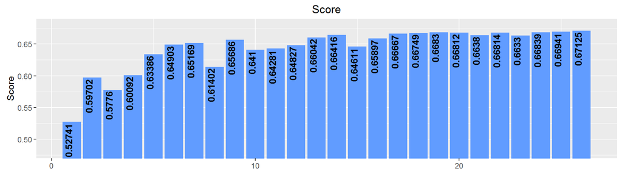

These were mostly single GBM with CV, Deep Learning, Ensembles and XgBoost (code: https://github.com/salacika/prudential-ds-ceu/blob/master/xg_final.R)

My aim to finish in top 25% was achieved, by the end of the competition, I ranked 638/2715. Then the second test with larger data came and many fall behind with over fitted models, so I end up as 214/2715 which is already top 10%: https://www.kaggle.com/salacika/results

The winner of the competition got 0.67939, my score with the first test was 0.67125 and then 0.67108 with second one (it seems my model was flexible enough, a slight over fit maybe).

It was a great fun, I plan do it again as soon as have time!

## Appendix 1. More statistics

Summary on columns:

```r
summary(appendixtrainlocal)
```

```
##        Id        Product_Info_1  Product_Info_2     Product_Info_3
##  Min.   :    2   Min.   :1.000   Length:59381       Min.   : 1.00
##  1st Qu.:19780   1st Qu.:1.000   Class :character   1st Qu.:26.00
##  Median :39487   Median :1.000   Mode  :character   Median :26.00
##  Mean   :39507   Mean   :1.026                      Mean   :24.42
##  3rd Qu.:59211   3rd Qu.:1.000                      3rd Qu.:26.00
##  Max.   :79146   Max.   :2.000                      Max.   :38.00
##
##  Product_Info_4    Product_Info_5  Product_Info_6  Product_Info_7
##  Min.   :0.00000   Min.   :2.000   Min.   :1.000   Min.   :1.000
##  1st Qu.:0.07692   1st Qu.:2.000   1st Qu.:3.000   1st Qu.:1.000
##  Median :0.23077   Median :2.000   Median :3.000   Median :1.000
##  Mean   :0.32895   Mean   :2.007   Mean   :2.674   Mean   :1.044
##  3rd Qu.:0.48718   3rd Qu.:2.000   3rd Qu.:3.000   3rd Qu.:1.000
##  Max.   :1.00000   Max.   :3.000   Max.   :3.000   Max.   :3.000
##
##     Ins_Age             Ht               Wt              BMI
##  Min.   :0.0000   Min.   :0.0000   Min.   :0.0000   Min.   :0.0000
##  1st Qu.:0.2388   1st Qu.:0.6545   1st Qu.:0.2259   1st Qu.:0.3855
##  Median :0.4030   Median :0.7091   Median :0.2887   Median :0.4513
##  Mean   :0.4056   Mean   :0.7073   Mean   :0.2926   Mean   :0.4695
##  3rd Qu.:0.5672   3rd Qu.:0.7636   3rd Qu.:0.3452   3rd Qu.:0.5329
##  Max.   :1.0000   Max.   :1.0000   Max.   :1.0000   Max.   :1.0000
##
##  Employment_Info_1 Employment_Info_2 Employment_Info_3 Employment_Info_4
##  Min.   :0.00000   Min.   : 1.000    Min.   :1.000     Min.   :0.000
##  1st Qu.:0.03500   1st Qu.: 9.000    1st Qu.:1.000     1st Qu.:0.000
##  Median :0.06000   Median : 9.000    Median :1.000     Median :0.000
##  Mean   :0.07758   Mean   : 8.642    Mean   :1.301     Mean   :0.006
##  3rd Qu.:0.10000   3rd Qu.: 9.000    3rd Qu.:1.000     3rd Qu.:0.000
##  Max.   :1.00000   Max.   :38.000    Max.   :3.000     Max.   :1.000
##  NA's   :19                                            NA's   :6779
##  Employment_Info_5 Employment_Info_6 InsuredInfo_1   InsuredInfo_2
##  Min.   :2.000     Min.   :0.000     Min.   :1.000   Min.   :2.000
##  1st Qu.:2.000     1st Qu.:0.060     1st Qu.:1.000   1st Qu.:2.000
##  Median :2.000     Median :0.250     Median :1.000   Median :2.000
##  Mean   :2.143     Mean   :0.361     Mean   :1.209   Mean   :2.007
##  3rd Qu.:2.000     3rd Qu.:0.550     3rd Qu.:1.000   3rd Qu.:2.000
##  Max.   :3.000     Max.   :1.000     Max.   :3.000   Max.   :3.000
##                    NA's   :10854
```

[output cut: 257 more lines]

```
##  Min.   :0.00000    Min.   :0.000000   Min.   :0.00000
##  1st Qu.:0.00000    1st Qu.:0.000000   1st Qu.:0.00000
##  Median :0.00000    Median :0.000000   Median :0.00000
##  Mean   :0.01369    Mean   :0.008488   Mean   :0.01991
##  3rd Qu.:0.00000    3rd Qu.:0.000000   3rd Qu.:0.00000
##  Max.   :1.00000    Max.   :1.000000   Max.   :1.00000
##
##  Medical_Keyword_48    Response
##  Min.   :0.0000     Min.   :1.000
##  1st Qu.:0.0000     1st Qu.:4.000
##  Median :0.0000     Median :6.000
##  Mean   :0.0545     Mean   :5.637
##  3rd Qu.:0.0000     3rd Qu.:8.000
##  Max.   :1.0000     Max.   :8.000
##
```

Number of NA’s by columns:

```r
sapply(appendixtrainlocal, function(x) sum(is.na(x)))
```

```
##                  Id      Product_Info_1      Product_Info_2
##                   0                   0                   0
##      Product_Info_3      Product_Info_4      Product_Info_5
##                   0                   0                   0
##      Product_Info_6      Product_Info_7             Ins_Age
##                   0                   0                   0
##                  Ht                  Wt                 BMI
##                   0                   0                   0
##   Employment_Info_1   Employment_Info_2   Employment_Info_3
##                  19                   0                   0
##   Employment_Info_4   Employment_Info_5   Employment_Info_6
##                6779                   0               10854
##       InsuredInfo_1       InsuredInfo_2       InsuredInfo_3
##                   0                   0                   0
##       InsuredInfo_4       InsuredInfo_5       InsuredInfo_6
##                   0                   0                   0
##       InsuredInfo_7 Insurance_History_1 Insurance_History_2
##                   0                   0                   0
## Insurance_History_3 Insurance_History_4 Insurance_History_5
##                   0                   0               25396
## Insurance_History_7 Insurance_History_8 Insurance_History_9
##                   0                   0                   0
##       Family_Hist_1       Family_Hist_2       Family_Hist_3
##                   0               28656               34241
##       Family_Hist_4       Family_Hist_5   Medical_History_1
##               19184               41811                8889
##   Medical_History_2   Medical_History_3   Medical_History_4
##                   0                   0                   0
##   Medical_History_5   Medical_History_6   Medical_History_7
##                   0                   0                   0
##   Medical_History_8   Medical_History_9  Medical_History_10
##                   0                   0               58824
##  Medical_History_11  Medical_History_12  Medical_History_13
##                   0                   0                   0
##  Medical_History_14  Medical_History_15  Medical_History_16
##                   0               44596                   0
##  Medical_History_17  Medical_History_18  Medical_History_19
##                   0                   0                   0
##  Medical_History_20  Medical_History_21  Medical_History_22
##                   0                   0                   0
```

[output cut: 31 more lines]

```
##                   0                   0                   0
##  Medical_Keyword_30  Medical_Keyword_31  Medical_Keyword_32
##                   0                   0                   0
##  Medical_Keyword_33  Medical_Keyword_34  Medical_Keyword_35
##                   0                   0                   0
##  Medical_Keyword_36  Medical_Keyword_37  Medical_Keyword_38
##                   0                   0                   0
##  Medical_Keyword_39  Medical_Keyword_40  Medical_Keyword_41
##                   0                   0                   0
##  Medical_Keyword_42  Medical_Keyword_43  Medical_Keyword_44
##                   0                   0                   0
##  Medical_Keyword_45  Medical_Keyword_46  Medical_Keyword_47
##                   0                   0                   0
##  Medical_Keyword_48            Response
##                   0                   0
```

Number of negative values by columns:

```r
sapply(appendixtrainlocal, function(x) sum(x<0, na.rm=TRUE))
```

```
##                  Id      Product_Info_1      Product_Info_2
##                   0                   0                   0
##      Product_Info_3      Product_Info_4      Product_Info_5
##                   0                   0                   0
##      Product_Info_6      Product_Info_7             Ins_Age
##                   0                   0                   0
##                  Ht                  Wt                 BMI
##                   0                   0                   0
##   Employment_Info_1   Employment_Info_2   Employment_Info_3
##                   0                   0                   0
##   Employment_Info_4   Employment_Info_5   Employment_Info_6
##                   0                   0                   0
##       InsuredInfo_1       InsuredInfo_2       InsuredInfo_3
##                   0                   0                   0
##       InsuredInfo_4       InsuredInfo_5       InsuredInfo_6
##                   0                   0                   0
##       InsuredInfo_7 Insurance_History_1 Insurance_History_2
##                   0                   0                   0
## Insurance_History_3 Insurance_History_4 Insurance_History_5
##                   0                   0                   0
## Insurance_History_7 Insurance_History_8 Insurance_History_9
##                   0                   0                   0
##       Family_Hist_1       Family_Hist_2       Family_Hist_3
##                   0                   0                   0
##       Family_Hist_4       Family_Hist_5   Medical_History_1
##                   0                   0                   0
##   Medical_History_2   Medical_History_3   Medical_History_4
##                   0                   0                   0
##   Medical_History_5   Medical_History_6   Medical_History_7
##                   0                   0                   0
##   Medical_History_8   Medical_History_9  Medical_History_10
##                   0                   0                   0
##  Medical_History_11  Medical_History_12  Medical_History_13
##                   0                   0                   0
##  Medical_History_14  Medical_History_15  Medical_History_16
##                   0                   0                   0
##  Medical_History_17  Medical_History_18  Medical_History_19
##                   0                   0                   0
##  Medical_History_20  Medical_History_21  Medical_History_22
##                   0                   0                   0
```

[output cut: 31 more lines]

```
##                   0                   0                   0
##  Medical_Keyword_30  Medical_Keyword_31  Medical_Keyword_32
##                   0                   0                   0
##  Medical_Keyword_33  Medical_Keyword_34  Medical_Keyword_35
##                   0                   0                   0
##  Medical_Keyword_36  Medical_Keyword_37  Medical_Keyword_38
##                   0                   0                   0
##  Medical_Keyword_39  Medical_Keyword_40  Medical_Keyword_41
##                   0                   0                   0
##  Medical_Keyword_42  Medical_Keyword_43  Medical_Keyword_44
##                   0                   0                   0
##  Medical_Keyword_45  Medical_Keyword_46  Medical_Keyword_47
##                   0                   0                   0
##  Medical_Keyword_48            Response
##                   0                   0
```

## Appendix 2. Code for dynamic wrapper generation used for ensembles

```
create_h2o_gbm_wrappers <- function(max_depths = c(8,9,10),learn_rates = c(0.02, 0.03)) {

  h2o_gbm_wrappers <- NULL

  for (i in seq(length(max_depths))) {
    for (j in seq(length(learn_rates))) {
      max_depth <- max_depths[i]
      learn_rate <- learn_rates[j]
      body <- sprintf(' <- function(..., learn_rate=%s, ntrees = 500, nbins=20, sample_rate=0.6, max_depth =%s)
        h2o.gbm.wrapper(...,learn_rate=learn_rate, ntrees = ntrees, nbins = nbins, max_depth =
          max_depth,sample_rate=sample_rate)',learn_rate, max_depth)
      eval(parse(text = paste('h2o.gbm.', i,j, body, sep = '')), envir = .GlobalEnv)
      h2o_gbm_wrappers <- c(h2o_gbm_wrappers,paste('h2o.gbm.', i,j, sep = ''))
    }
  }
  return(h2o_gbm_wrappers)
}





create_h2o_rf_wrappers <- function(nbins = c(20,100,200),sample_rates = c(0.1, 0.632,0.9)) {

  h2o_rf_wrappers <- NULL

  for (i in seq(length(nbins))) {
    for (j in seq(length(sample_rates))) {
      nbin <- nbins[i]
      sample_rate <- sample_rates[j]
      body <- sprintf(' <- function(..., ntrees =250, nbins = %s,seed = 1,sample_rate = %s)
        h2o.randomForest.wrapper(..., ntrees = ntrees, nbins = nbins,sample_rate = sample_rate, seed = seed)', nbin,sample_rate)
      eval(parse(text = paste('h2o.rf.', i,j, body, sep = '')), envir = .GlobalEnv)
      print(eval(parse(text = paste('h2o.rf.', i,j, body, sep = '')), envir = .GlobalEnv))
      h2o_rf_wrappers <- c(h2o_rf_wrappers,paste('h2o.gbm.', i,j, sep = ''))
    }
  }
  return(h2o_rf_wrappers)
}
```